# scRNA-seq Dimension Reduction

**CCDL 2019**

In this notebook, we’ll use dimension reduction techniques on single-cell RNA-seq data.

As compared to bulk RNA-seq data, single cell RNA-seq data generally has more dimensions, (since we have data points for each individual cell level rather than the tissue as a whole). Because of this, its common to use dimension reduction techniques so all of the data is in a more easily manageable form for plotting, clustering, or other downstream analyses.

## Set Up

```r
# Load libraries
library(ggplot2)
# Magrittr pipe
`%>%` <- dplyr::`%>%`
# Setting the seed so our t-SNE is reproducible
set.seed(12345)
```

For this module, we are going to use the dataset that we processed part of in `02-tag-based_pre-processing_scRNA-seq.md` We have already filtered and `scran` normalized this data for you (following the same steps we did in `01-normalizing_scRNA-seq.Rmd`, but using slightly different cutoffs). We also randomly selected 500 cells, and are only using the top 95% highest average expression genes from these 500 cells.

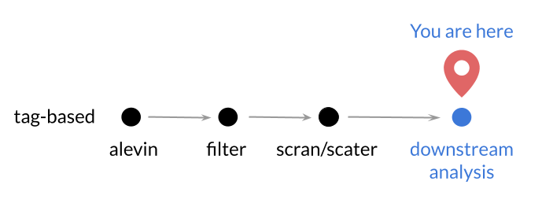

**Status of the current dataset**

## Directories and files

```r
# Directory where the gene matrix is
gene_matrix_file <- file.path("data", "tabula_muris", "normalized",
                              "scran_norm_tab_mur.tsv")
# Directory where the metadata file is
metadata_file <- file.path("data", "tabula_muris", "normalized",
                           "tab_mur_metadata.tsv")
```

## Import the gene matrix and metadata

```r
# Read in normalized gene matrix
tab_mur_data <- readr::read_tsv(gene_matrix_file, progress = FALSE)
# Read in associated metadata
tab_mur_meta <- readr::read_tsv(metadata_file, progress = FALSE)
```

## Principal Components Analysis

Just like we did with our other scRNA-seq data, we will also run PCA with this dataset. Before we do that, we are going to go ahead and transpose our matrix, since we will need a sample x gene matrix for our dimension reduction in the following steps.

```r
# Transpose our matrix
transposed_data <- t(tab_mur_data)
```

Now let’s used the transposed data to obtain PCA scores for our samples.

```r
# Run PCA
pca_tab_mur <- prcomp(transposed_data)
# Make a dataframe with these PCA scores
pca_tab_mur <- data.frame(pca_tab_mur$x[, 1:2],
                          tissue = as.factor(tab_mur_meta$tissue))
```

Let’s plot our first two principal components and label our cells with what tissue they are from.

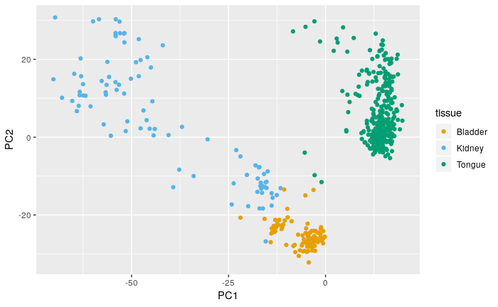

```r
# Plot this with ggplot2 and label the points with cell types
ggplot(pca_tab_mur, aes(x = PC1, y = PC2, color = tissue)) +
  geom_point() +
  # Add this so our color palette is colorblindness friendly
  colorblindr::scale_color_OkabeIto()
```

## t-SNE experiment

t-SNE is a popular dimension reduction technique that has become even more popular with single-cell RNA-seq data analysis. It would be a good use of our time to explore t-SNE parameters and how they affect the outcomes. First, let’s run our data through t-SNE on default parameters and see what our data looks like with a `ggplot2` scatterplot. Here we will be using the R package, `Rtsne` to perform t-SNE. Although packages like `scater` have built in methods for performing dimension reduction (`scater::runTSNE`), we want to show you a method that can be applied to most any data so long as it is in a matrix.

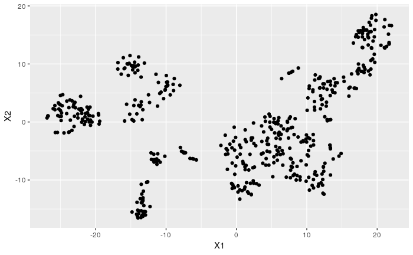

```r
# Run t-SNE using the Rtsne package
tsne_tab_mur <- Rtsne::Rtsne(transposed_data)
# Make this a data.frame so ggplot will like it
# Note that Y is the output coordinates from Rtsne
tsne_data <- data.frame(tsne_tab_mur$Y)

# Plot this with ggplot2
ggplot(tsne_data, aes(x = X1, y = X2)) +
  geom_point() +
  colorblindr::scale_color_OkabeIto()
```

#### Apply metadata labels to our t-SNE

Let’s re-plot this with labels using some of our metadata to see how the cells are clustering (or not clustering) by different variables. Remember that `tab_mur_meta` has the corresponding information for each of our cells. Below we have set up the cells to be colored by the `tissue` variable. Run this, but also feel free to look at what other information we have for these cells in `tab_mur_meta` by using `str()` and change this to a different variable to graph it by.

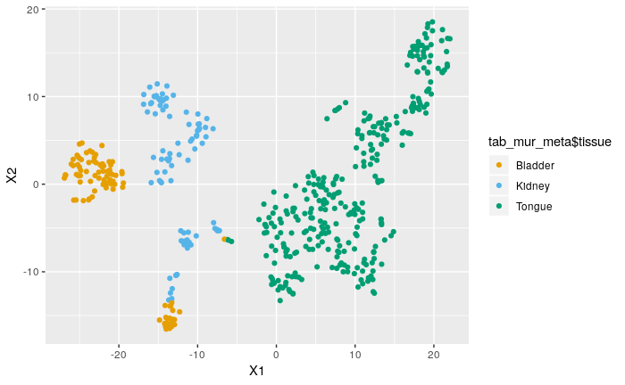

```r
# Plot this with ggplot2, but add the color argument
ggplot(tsne_data, aes(x = X1, y = X2, color = tab_mur_meta$tissue)) +
  geom_point() +
  colorblindr::scale_color_OkabeIto()
```

Now that we have an idea of what the default parameters look like, let’s try experimenting with the perplexity parameter. For us to determine a good number range to use for testing perplexity, let’s first look up the documentation for `Rtsne::Rtsne` and find out what the default for the `perplexity` argument is.

In order to prepare for this experiment, we will create a *function* that allows us to rerun this same code chunk easily, but create an argument that allows us to change one variable: our perplexity variable.

```r
TsnePlotWrapper <- function(perplexity_param = 30) {
  # Purpose: Run t-SNE and plot the output
  # Args: perplexity_param: a single numeric argument that will change the
  #                         perplexity variable in the Rtsne function.
  # Output: a ggplot scatterplot with the two t-SNE coordinates plotted and
  #         cell-types labeled with data point colors.
  # Run t-SNE but set the perplexity parameter
  tsne_tab_mur <- Rtsne::Rtsne(transposed_data, perplexity = perplexity_param)
  # Make this a data.frame so ggplot will like it
  tsne <- data.frame(tsne_tab_mur$Y)

  # Plot this with ggplot2
  ggplot(tsne, aes(x = X1, y = X2, color = tab_mur_meta$tissue)) +
    geom_point() +
    colorblindr::scale_color_OkabeIto()
}
```

Fill in the next five code chunks with the function and the perplexity argument you would like to use for each. Then run the chunks and compare your output graphs.

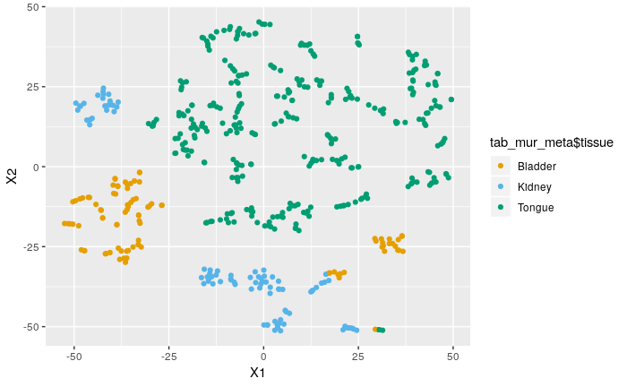

```r
# We've set up the first example for you
TsnePlotWrapper(perplexity_param = 3)
```

```r
# Run tSNE_plot_wrapper function for a second time, but use a different perplexity
# argument
```

```r
# Run tSNE_plot_wrapper function for a third time, but use a different perplexity
# argument
```

```r
# Run tSNE_plot_wrapper function for a fourth time, but use a different perplexity
# argument
```

```r
# Run tSNE_plot_wrapper function for a fifth time, but use a different perplexity
# argument
```

#### Some ‘big picture’ thoughts to take from this experiment:

1. Different analyses (such as t-SNE) have various limitations for interpretability. We found in our experiment that the coordinates of t-SNE output for any given cell might change drastically. This probably means that you shouldn’t rely too heavily on the exact values of t-SNE’s output.
2. Different analyses also have their strengths.  
   Using cell-type labeling, our experiment illustrated that t-SNE does appear to give some biologically relevant output information for this dataset.
3. Playing with parameters so you can fine-tune them is a good way to give you more information about a particular analysis as well as the data itself.

In summary, if the results of an analysis can be completely changed by changing its parameters, you should be more cautious when it comes to the conclusions you draw from it as well as having good rationale for the parameters you choose.

### For further reading on dimension reduction:

- [Wattenberg et al](https://distill.pub/2016/misread-tsne/) discuss how to use t-SNE properly with great visuals.
- [Nyguen & Holmes *PLoS Comput Biol* 2019.](https://journals.plos.org/ploscompbiol/article/file?id=10.1371/journal.pcbi.1006907&type=printable) lay out guidelines on choosing dimensions reduction methods.
- [Becht et al *Nature Biotechnology* 2018.](https://www.nature.com/articles/nbt.4314) discusses using [UMAP](https://github.com/lmcinnes/umap) for single-cell data.
- This website explains [PCA visually](http://setosa.io/ev/principal-component-analysis/).

**Single-cell specific dimension reduction methods to consider:**  
- [VASC](https://www.sciencedirect.com/science/article/pii/S167202291830439X)  
- [scVI](https://scvi.readthedocs.io/en/master/readme.html)